# Risk Factor Analysis

## Outcome Variable

**Outcome Variable:** co_occurence

## Predictor Variables

**Intervention Variable:** ever_co06

**Adjustment Set:**

- sex
- arm
- enstunt
- month
- brthmon
- hhwealth_quart
- W_birthwt
- W_birthlen
- W_mage
- W_mhtcm
- W_meducyrs
- W_feducyrs
- delta_month
- delta_brthmon
- delta_hhwealth_quart
- delta_W_birthwt
- delta_W_birthlen
- delta_W_mage
- delta_W_mhtcm
- delta_W_meducyrs
- delta_W_feducyrs

## Stratifying Variables

The analysis was stratified on these variable(s):

- studyid
- country

## Data Summary

| studyid | country | ever_co06 | co_occurence | n_cell | n |
| --- | --- | --- | --- | --- | --- |
| ki0047075b-MAL-ED | BANGLADESH | 0 | 0 | 202 | 221 |
| ki0047075b-MAL-ED | BANGLADESH | 0 | 1 | 12 | 221 |
| ki0047075b-MAL-ED | BANGLADESH | 1 | 0 | 5 | 221 |
| ki0047075b-MAL-ED | BANGLADESH | 1 | 1 | 2 | 221 |
| ki0047075b-MAL-ED | BRAZIL | 0 | 0 | 179 | 180 |
| ki0047075b-MAL-ED | BRAZIL | 0 | 1 | 1 | 180 |
| ki0047075b-MAL-ED | BRAZIL | 1 | 0 | 0 | 180 |
| ki0047075b-MAL-ED | BRAZIL | 1 | 1 | 0 | 180 |
| ki0047075b-MAL-ED | INDIA | 0 | 0 | 198 | 228 |
| ki0047075b-MAL-ED | INDIA | 0 | 1 | 13 | 228 |
| ki0047075b-MAL-ED | INDIA | 1 | 0 | 13 | 228 |
| ki0047075b-MAL-ED | INDIA | 1 | 1 | 4 | 228 |
| ki0047075b-MAL-ED | NEPAL | 0 | 0 | 220 | 229 |
| ki0047075b-MAL-ED | NEPAL | 0 | 1 | 3 | 229 |
| ki0047075b-MAL-ED | NEPAL | 1 | 0 | 5 | 229 |
| ki0047075b-MAL-ED | NEPAL | 1 | 1 | 1 | 229 |
| ki0047075b-MAL-ED | PERU | 0 | 0 | 216 | 222 |
| ki0047075b-MAL-ED | PERU | 0 | 1 | 5 | 222 |
| ki0047075b-MAL-ED | PERU | 1 | 0 | 0 | 222 |
| ki0047075b-MAL-ED | PERU | 1 | 1 | 1 | 222 |
| ki0047075b-MAL-ED | SOUTH AFRICA | 0 | 0 | 232 | 241 |
| ki0047075b-MAL-ED | SOUTH AFRICA | 0 | 1 | 4 | 241 |
| ki0047075b-MAL-ED | SOUTH AFRICA | 1 | 0 | 5 | 241 |
| ki0047075b-MAL-ED | SOUTH AFRICA | 1 | 1 | 0 | 241 |
| ki0047075b-MAL-ED | TANZANIA, UNITED REPUBLIC OF | 0 | 0 | 220 | 225 |
| ki0047075b-MAL-ED | TANZANIA, UNITED REPUBLIC OF | 0 | 1 | 1 | 225 |
| ki0047075b-MAL-ED | TANZANIA, UNITED REPUBLIC OF | 1 | 0 | 4 | 225 |
| ki0047075b-MAL-ED | TANZANIA, UNITED REPUBLIC OF | 1 | 1 | 0 | 225 |
| ki1000108-CMC-V-BCS-2002 | INDIA | 0 | 0 | 319 | 366 |
| ki1000108-CMC-V-BCS-2002 | INDIA | 0 | 1 | 16 | 366 |

[output cut: 90 more lines]

The following strata were considered:

- studyid: ki0047075b-MAL-ED, country: BANGLADESH
- studyid: ki0047075b-MAL-ED, country: BRAZIL
- studyid: ki0047075b-MAL-ED, country: INDIA
- studyid: ki0047075b-MAL-ED, country: NEPAL
- studyid: ki0047075b-MAL-ED, country: PERU
- studyid: ki0047075b-MAL-ED, country: SOUTH AFRICA
- studyid: ki0047075b-MAL-ED, country: TANZANIA, UNITED REPUBLIC OF
- studyid: ki1000108-CMC-V-BCS-2002, country: INDIA
- studyid: ki1000108-IRC, country: INDIA
- studyid: ki1000109-EE, country: PAKISTAN
- studyid: ki1000109-ResPak, country: PAKISTAN
- studyid: ki1000304b-SAS-CompFeed, country: INDIA
- studyid: ki1000304b-SAS-FoodSuppl, country: INDIA
- studyid: ki1017093-NIH-Birth, country: BANGLADESH
- studyid: ki1017093b-PROVIDE, country: BANGLADESH
- studyid: ki1017093c-NIH-Crypto, country: BANGLADESH
- studyid: ki1066203-TanzaniaChild2, country: TANZANIA, UNITED REPUBLIC OF
- studyid: ki1101329-Keneba, country: GAMBIA
- studyid: ki1113344-GMS-Nepal, country: NEPAL
- studyid: ki1114097-CMIN, country: BANGLADESH
- studyid: ki1114097-CMIN, country: BRAZIL
- studyid: ki1114097-CMIN, country: GUINEA-BISSAU
- studyid: ki1114097-CMIN, country: PERU
- studyid: ki1114097-CONTENT, country: PERU
- studyid: ki1119695-PROBIT, country: BELARUS
- studyid: ki1126311-ZVITAMBO, country: ZIMBABWE
- studyid: ki1135781-COHORTS, country: GUATEMALA
- studyid: ki1135781-COHORTS, country: PHILIPPINES
- studyid: ki1148112-LCNI-5, country: MALAWI
- studyid: kiGH5241-JiVitA-4, country: BANGLADESH

### Dropped Strata

Some strata were dropped due to rare outcomes:

- studyid: ki0047075b-MAL-ED, country: BANGLADESH
- studyid: ki0047075b-MAL-ED, country: BRAZIL
- studyid: ki0047075b-MAL-ED, country: INDIA
- studyid: ki0047075b-MAL-ED, country: NEPAL
- studyid: ki0047075b-MAL-ED, country: PERU
- studyid: ki0047075b-MAL-ED, country: SOUTH AFRICA
- studyid: ki0047075b-MAL-ED, country: TANZANIA, UNITED REPUBLIC OF
- studyid: ki1000109-ResPak, country: PAKISTAN
- studyid: ki1066203-TanzaniaChild2, country: TANZANIA, UNITED REPUBLIC OF
- studyid: ki1114097-CMIN, country: BRAZIL
- studyid: ki1114097-CMIN, country: GUINEA-BISSAU
- studyid: ki1114097-CMIN, country: PERU
- studyid: ki1114097-CONTENT, country: PERU
- studyid: ki1119695-PROBIT, country: BELARUS
- studyid: ki1135781-COHORTS, country: GUATEMALA
- studyid: ki1148112-LCNI-5, country: MALAWI

## Methods Detail

We’re interested in the causal parameters $E[Y_a]$ for all values of $a \in \mathcal{A}$. These parameters represent the mean outcome if, possibly contrary to fact, we intervened to set all units to have $A=a$. Under the randomization and positivity assumptions, these are identified by the statistical parameters $\psi_a=E_W[E_{Y|A,W}(Y|A=a,W)]$. In addition, we’re interested in the mean of $Y$, $E[Y]$ under no intervention (the observed mean). We will estimate these parameters by using SuperLearner to fit the relevant likelihood factors – $E_{Y|A,W}(Y|A=a,W)$ and $p(A=a|W)$, and then updating our likelihood fit using a joint TMLE.

For unadjusted analyses ($W=\{\}$), initial likelihoods were estimated using Lrnr_glm to estimate the simple $E(Y|A)$ and Lrnr_mean to estimate $p(A)$. For adjusted analyses, a small library containing Lrnr_glmnet, Lrnr_xgboost, and Lrnr_mean was used.

Having estimated these parameters, we will then use the delta method to estimate relative risks and attributable risks relative to a prespecified baseline level of $A$.

# Results Detail

## Results Plots

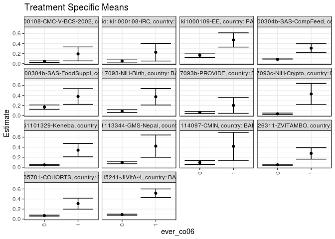

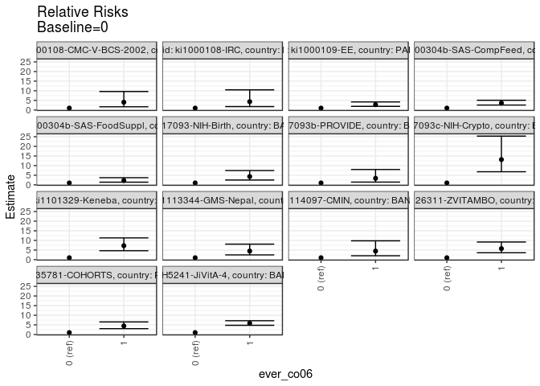

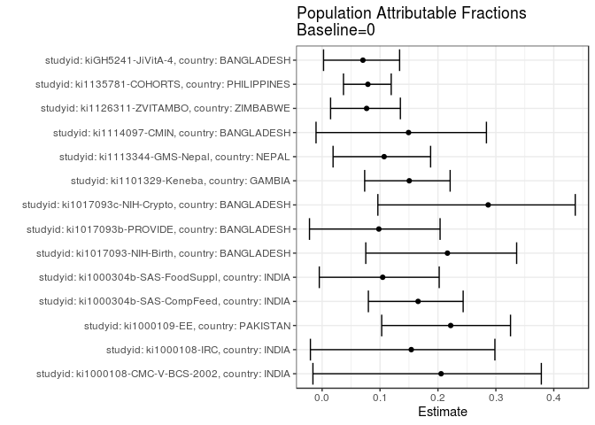

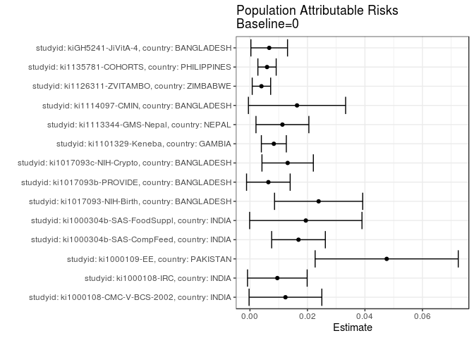

## Results Table

### Parameter: TSM

| studyid | country | intervention_level | baseline_level | estimate | ci_lower | ci_upper |
| --- | --- | --- | --- | --- | --- | --- |
| ki1000108-CMC-V-BCS-2002 | INDIA | 0 | NA | 0.0477612 | 0.0248931 | 0.0706293 |
| ki1000108-CMC-V-BCS-2002 | INDIA | 1 | NA | 0.1935484 | 0.0542823 | 0.3328144 |
| ki1000108-IRC | INDIA | 0 | NA | 0.0523560 | 0.0299915 | 0.0747206 |
| ki1000108-IRC | INDIA | 1 | NA | 0.2272727 | 0.0519405 | 0.4026049 |
| ki1000109-EE | PAKISTAN | 0 | NA | 0.1667167 | 0.1241613 | 0.2092720 |
| ki1000109-EE | PAKISTAN | 1 | NA | 0.4722137 | 0.3299446 | 0.6144828 |
| ki1000304b-SAS-CompFeed | INDIA | 0 | NA | 0.0850244 | 0.0753551 | 0.0946938 |
| ki1000304b-SAS-CompFeed | INDIA | 1 | NA | 0.3082002 | 0.2188939 | 0.3975064 |
| ki1000304b-SAS-FoodSuppl | INDIA | 0 | NA | 0.1663288 | 0.1231295 | 0.2095281 |
| ki1000304b-SAS-FoodSuppl | INDIA | 1 | NA | 0.3783362 | 0.2214873 | 0.5351852 |
| ki1017093-NIH-Birth | BANGLADESH | 0 | NA | 0.0865028 | 0.0593751 | 0.1136304 |
| ki1017093-NIH-Birth | BANGLADESH | 1 | NA | 0.3729368 | 0.2082884 | 0.5375852 |
| ki1017093b-PROVIDE | BANGLADESH | 0 | NA | 0.0589354 | 0.0387913 | 0.0790794 |
| ki1017093b-PROVIDE | BANGLADESH | 1 | NA | 0.2000000 | 0.0430604 | 0.3569396 |
| ki1017093c-NIH-Crypto | BANGLADESH | 0 | NA | 0.0326264 | 0.0185516 | 0.0467012 |
| ki1017093c-NIH-Crypto | BANGLADESH | 1 | NA | 0.4285714 | 0.2167481 | 0.6403948 |
| ki1101329-Keneba | GAMBIA | 0 | NA | 0.0469013 | 0.0368727 | 0.0569300 |
| ki1101329-Keneba | GAMBIA | 1 | NA | 0.3404746 | 0.2080323 | 0.4729170 |
| ki1113344-GMS-Nepal | NEPAL | 0 | NA | 0.0941620 | 0.0692986 | 0.1190253 |
| ki1113344-GMS-Nepal | NEPAL | 1 | NA | 0.4210526 | 0.1988474 | 0.6432578 |
| ki1114097-CMIN | BANGLADESH | 0 | NA | 0.0933333 | 0.0552428 | 0.1314239 |
| ki1114097-CMIN | BANGLADESH | 1 | NA | 0.4166667 | 0.1371367 | 0.6961967 |
| ki1126311-ZVITAMBO | ZIMBABWE | 0 | NA | 0.0479705 | 0.0375004 | 0.0584405 |
| ki1126311-ZVITAMBO | ZIMBABWE | 1 | NA | 0.2758621 | 0.1618116 | 0.3899125 |
| ki1135781-COHORTS | PHILIPPINES | 0 | NA | 0.0692506 | 0.0591371 | 0.0793640 |
| ki1135781-COHORTS | PHILIPPINES | 1 | NA | 0.3076678 | 0.1983055 | 0.4170300 |
| kiGH5241-JiVitA-4 | BANGLADESH | 0 | NA | 0.0883717 | 0.0778891 | 0.0988543 |
| kiGH5241-JiVitA-4 | BANGLADESH | 1 | NA | 0.5159325 | 0.4313019 | 0.6005631 |

### Parameter: E(Y)

| studyid | country | intervention_level | baseline_level | estimate | ci_lower | ci_upper |
| --- | --- | --- | --- | --- | --- | --- |
| ki1000108-CMC-V-BCS-2002 | INDIA | NA | NA | 0.0601093 | 0.0357249 | 0.0844936 |
| ki1000108-IRC | INDIA | NA | NA | 0.0618812 | 0.0383576 | 0.0854048 |
| ki1000109-EE | PAKISTAN | NA | NA | 0.2142857 | 0.1712366 | 0.2573348 |
| ki1000304b-SAS-CompFeed | INDIA | NA | NA | 0.1019108 | 0.0902026 | 0.1136190 |
| ki1000304b-SAS-FoodSuppl | INDIA | NA | NA | 0.1857585 | 0.1432798 | 0.2282372 |
| ki1017093-NIH-Birth | BANGLADESH | NA | NA | 0.1103896 | 0.0817833 | 0.1389959 |
| ki1017093b-PROVIDE | BANGLADESH | NA | NA | 0.0653358 | 0.0446834 | 0.0859881 |
| ki1017093c-NIH-Crypto | BANGLADESH | NA | NA | 0.0457413 | 0.0294659 | 0.0620168 |
| ki1101329-Keneba | GAMBIA | NA | NA | 0.0552077 | 0.0445257 | 0.0658898 |
| ki1113344-GMS-Nepal | NEPAL | NA | NA | 0.1054545 | 0.0797627 | 0.1311464 |
| ki1114097-CMIN | BANGLADESH | NA | NA | 0.1097046 | 0.0698323 | 0.1495770 |
| ki1126311-ZVITAMBO | ZIMBABWE | NA | NA | 0.0519637 | 0.0412672 | 0.0626603 |
| ki1135781-COHORTS | PHILIPPINES | NA | NA | 0.0751910 | 0.0648251 | 0.0855569 |
| kiGH5241-JiVitA-4 | BANGLADESH | NA | NA | 0.0950696 | 0.0850280 | 0.1051113 |

### Parameter: RR

| studyid | country | intervention_level | baseline_level | estimate | ci_lower | ci_upper |
| --- | --- | --- | --- | --- | --- | --- |
| ki1000108-CMC-V-BCS-2002 | INDIA | 0 | 0 | 1.000000 | 1.000000 | 1.000000 |
| ki1000108-CMC-V-BCS-2002 | INDIA | 1 | 0 | 4.052419 | 1.707496 | 9.617650 |
| ki1000108-IRC | INDIA | 0 | 0 | 1.000000 | 1.000000 | 1.000000 |
| ki1000108-IRC | INDIA | 1 | 0 | 4.340909 | 1.797246 | 10.484651 |
| ki1000109-EE | PAKISTAN | 0 | 0 | 1.000000 | 1.000000 | 1.000000 |
| ki1000109-EE | PAKISTAN | 1 | 0 | 2.832433 | 1.904707 | 4.212026 |
| ki1000304b-SAS-CompFeed | INDIA | 0 | 0 | 1.000000 | 1.000000 | 1.000000 |
| ki1000304b-SAS-CompFeed | INDIA | 1 | 0 | 3.624842 | 2.586935 | 5.079167 |
| ki1000304b-SAS-FoodSuppl | INDIA | 0 | 0 | 1.000000 | 1.000000 | 1.000000 |
| ki1000304b-SAS-FoodSuppl | INDIA | 1 | 0 | 2.274628 | 1.393249 | 3.713576 |
| ki1017093-NIH-Birth | BANGLADESH | 0 | 0 | 1.000000 | 1.000000 | 1.000000 |
| ki1017093-NIH-Birth | BANGLADESH | 1 | 0 | 4.311271 | 2.506009 | 7.416997 |
| ki1017093b-PROVIDE | BANGLADESH | 0 | 0 | 1.000000 | 1.000000 | 1.000000 |
| ki1017093b-PROVIDE | BANGLADESH | 1 | 0 | 3.393548 | 1.441910 | 7.986748 |
| ki1017093c-NIH-Crypto | BANGLADESH | 0 | 0 | 1.000000 | 1.000000 | 1.000000 |
| ki1017093c-NIH-Crypto | BANGLADESH | 1 | 0 | 13.135714 | 6.816156 | 25.314412 |
| ki1101329-Keneba | GAMBIA | 0 | 0 | 1.000000 | 1.000000 | 1.000000 |
| ki1101329-Keneba | GAMBIA | 1 | 0 | 7.259384 | 4.660823 | 11.306725 |
| ki1113344-GMS-Nepal | NEPAL | 0 | 0 | 1.000000 | 1.000000 | 1.000000 |
| ki1113344-GMS-Nepal | NEPAL | 1 | 0 | 4.471579 | 2.478449 | 8.067553 |
| ki1114097-CMIN | BANGLADESH | 0 | 0 | 1.000000 | 1.000000 | 1.000000 |
| ki1114097-CMIN | BANGLADESH | 1 | 0 | 4.464286 | 2.035729 | 9.790027 |
| ki1126311-ZVITAMBO | ZIMBABWE | 0 | 0 | 1.000000 | 1.000000 | 1.000000 |
| ki1126311-ZVITAMBO | ZIMBABWE | 1 | 0 | 5.750663 | 3.603143 | 9.178133 |
| ki1135781-COHORTS | PHILIPPINES | 0 | 0 | 1.000000 | 1.000000 | 1.000000 |
| ki1135781-COHORTS | PHILIPPINES | 1 | 0 | 4.442820 | 3.024884 | 6.525425 |
| kiGH5241-JiVitA-4 | BANGLADESH | 0 | 0 | 1.000000 | 1.000000 | 1.000000 |
| kiGH5241-JiVitA-4 | BANGLADESH | 1 | 0 | 5.838209 | 4.771629 | 7.143197 |

### Parameter: PAR

| studyid | country | intervention_level | baseline_level | estimate | ci_lower | ci_upper |
| --- | --- | --- | --- | --- | --- | --- |
| ki1000108-CMC-V-BCS-2002 | INDIA | 0 | NA | 0.0123481 | -0.0003102 | 0.0250064 |
| ki1000108-IRC | INDIA | 0 | NA | 0.0095252 | -0.0008508 | 0.0199011 |
| ki1000109-EE | PAKISTAN | 0 | NA | 0.0475691 | 0.0226732 | 0.0724649 |
| ki1000304b-SAS-CompFeed | INDIA | 0 | NA | 0.0168864 | 0.0075463 | 0.0262264 |
| ki1000304b-SAS-FoodSuppl | INDIA | 0 | NA | 0.0194297 | -0.0001111 | 0.0389705 |
| ki1017093-NIH-Birth | BANGLADESH | 0 | NA | 0.0238869 | 0.0085489 | 0.0392248 |
| ki1017093b-PROVIDE | BANGLADESH | 0 | NA | 0.0064004 | -0.0011864 | 0.0139872 |
| ki1017093c-NIH-Crypto | BANGLADESH | 0 | NA | 0.0131149 | 0.0041754 | 0.0220544 |
| ki1101329-Keneba | GAMBIA | 0 | NA | 0.0083064 | 0.0039659 | 0.0126470 |
| ki1113344-GMS-Nepal | NEPAL | 0 | NA | 0.0112926 | 0.0020948 | 0.0204904 |
| ki1114097-CMIN | BANGLADESH | 0 | NA | 0.0163713 | -0.0005355 | 0.0332781 |
| ki1126311-ZVITAMBO | ZIMBABWE | 0 | NA | 0.0039933 | 0.0007878 | 0.0071987 |
| ki1135781-COHORTS | PHILIPPINES | 0 | NA | 0.0059404 | 0.0027579 | 0.0091230 |
| kiGH5241-JiVitA-4 | BANGLADESH | 0 | NA | 0.0066979 | 0.0003245 | 0.0130714 |

### Parameter: PAF

| studyid | country | intervention_level | baseline_level | estimate | ci_lower | ci_upper |
| --- | --- | --- | --- | --- | --- | --- |
| ki1000108-CMC-V-BCS-2002 | INDIA | 0 | NA | 0.2054274 | -0.0158579 | 0.3785099 |
| ki1000108-IRC | INDIA | 0 | NA | 0.1539267 | -0.0202056 | 0.2983375 |
| ki1000109-EE | PAKISTAN | 0 | NA | 0.2219889 | 0.1028620 | 0.3252975 |
| ki1000304b-SAS-CompFeed | INDIA | 0 | NA | 0.1656976 | 0.0798642 | 0.2435242 |
| ki1000304b-SAS-FoodSuppl | INDIA | 0 | NA | 0.1045965 | -0.0048809 | 0.2021469 |
| ki1017093-NIH-Birth | BANGLADESH | 0 | NA | 0.2163869 | 0.0753957 | 0.3358785 |
| ki1017093b-PROVIDE | BANGLADESH | 0 | NA | 0.0979616 | -0.0218027 | 0.2036884 |
| ki1017093c-NIH-Crypto | BANGLADESH | 0 | NA | 0.2867188 | 0.0962517 | 0.4370445 |
| ki1101329-Keneba | GAMBIA | 0 | NA | 0.1504576 | 0.0734725 | 0.2210459 |
| ki1113344-GMS-Nepal | NEPAL | 0 | NA | 0.1070849 | 0.0189153 | 0.1873307 |
| ki1114097-CMIN | BANGLADESH | 0 | NA | 0.1492308 | -0.0104896 | 0.2837053 |
| ki1126311-ZVITAMBO | ZIMBABWE | 0 | NA | 0.0768472 | 0.0146189 | 0.1351456 |
| ki1135781-COHORTS | PHILIPPINES | 0 | NA | 0.0790047 | 0.0368831 | 0.1192841 |
| kiGH5241-JiVitA-4 | BANGLADESH | 0 | NA | 0.0704530 | 0.0024808 | 0.1337935 |